# Model Building

## Project Data

#### Importing the file

```r
project_orig <- fread("opendata_projects000/opendata_projects000.csv", sep = ",", header = FALSE, data.table = FALSE, col.names = c('_projectid', '_teacher_acctid', '_schoolid', 'school_ncesid', 'school_latitude', 'school_longitude', 'school_city', 'school_state', 'school_zip', 'school_metro', 'school_district', 'school_county', 'school_charter', 'school_magnet', 'school_year_round', 'school_nlns', 'school_kipp', 'school_charter_ready_promise', 'teacher_prefix', 'teacher_teach_for_america', 'teacher_ny_teaching_fellow', 'primary_focus_subject', 'primary_focus_area' ,'secondary_focus_subject', 'secondary_focus_area', 'resource_type', 'poverty_level', 'grade_level', 'vendor_shipping_charges', 'sales_tax', 'payment_processing_charges', 'fulfillment_labor_materials', 'total_price_excluding_optional_support', 'total_price_including_optional_support', 'students_reached', 'total_donations', 'num_donors', 'eligible_double_your_impact_match', 'eligible_almost_home_match', 'funding_status', 'date_posted', 'date_completed', 'date_thank_you_packet_mailed', 'date_expiration'))
```

[output not shown]

#### Cleaning the data

```r
project <- tbl_df(project_orig)

project$school_latitude <- as.double(project$school_latitude)
project$school_longitude <- as.double(project$school_longitude)

project$school_city <- as.factor(project$school_city)
project$school_state <- as.factor(project$school_state)
project$school_zip <- as.factor(project$school_zip)
project$school_metro <- as.factor(project$school_metro)
project$school_district <- as.factor(project$school_district)
project$school_county <- as.factor(project$school_county)

project$school_charter <- as.integer(as.logical(toupper(project$school_charter)))
project$school_magnet <- as.integer(as.logical(toupper(project$school_magnet)))
project$school_year_round <- as.integer(as.logical(toupper(project$school_year_round)))
project$school_nlns <- as.integer(as.logical(toupper(project$school_nlns)))
project$school_kipp <- as.integer(as.logical(toupper(project$school_kipp)))
project$school_charter_ready_promise <- as.integer(as.logical(toupper(project$school_charter_ready_promise)))

project$teacher_prefix <- as.factor(project$teacher_prefix)

project$teacher_teach_for_america <- as.integer(as.logical(toupper(project$teacher_teach_for_america)))
project$teacher_ny_teaching_fellow <- as.integer(as.logical(toupper(project$teacher_ny_teaching_fellow)))

project$primary_focus_subject <- as.factor(project$primary_focus_subject)
project$primary_focus_area <- as.factor(project$primary_focus_area)
project$secondary_focus_subject <- as.factor(project$secondary_focus_subject)
project$secondary_focus_area <- as.factor(project$secondary_focus_area)

project$resource_type <- as.factor(project$resource_type)
project$poverty_level <- as.factor(project$poverty_level)
project$grade_level <- as.factor(project$grade_level)

project$vendor_shipping_charges <- as.double(project$vendor_shipping_charges)
project$sales_tax <- as.double(project$sales_tax)
project$payment_processing_charges <- as.double(project$payment_processing_charges)
project$fulfillment_labor_materials <- as.double(project$fulfillment_labor_materials)
project$total_price_excluding_optional_support <- as.double(project$total_price_excluding_optional_support)
project$total_price_including_optional_support <- as.double(project$total_price_including_optional_support)

project$students_reached <- as.integer(project$students_reached)
project$total_donations <- as.integer(project$total_donations)
project$num_donors <- as.integer(project$num_donors)

project$eligible_double_your_impact_match <- as.integer(as.logical(toupper(project$eligible_double_your_impact_match)))
project$eligible_almost_home_match <- as.integer(as.logical(toupper(project$eligible_almost_home_match)))

project$funding_status <- as.factor(project$funding_status)

project$date_posted <- as.Date(project$date_posted)
project$date_completed <- as.Date(project$date_completed)
project$date_thank_you_packet_mailed <- as.Date(project$date_thank_you_packet_mailed)
project$date_expiration <- as.Date(project$date_expiration)

project$grade_level <- factor(project$grade_level, levels = c("", "Grades PreK-2", "Grades 3-5", "Grades 6-8", "Grades 9-12"))
project$poverty_level <- factor(project$poverty_level, levels = c("", "low poverty", "moderate poverty", "high poverty", "highest poverty"))
```

#### Funding status and Date Posted

We will only focus on projects that are either completed (successfully funded) or expired (did not reach funding goal), and remove the live and reallocated projects. To limit the scope of the analysis, we will only focus on projects posted in 2015.

```r
project <- project %>% filter(funding_status == "completed" | funding_status == "expired")
project$funding_status <- droplevels(project$funding_status)

project <- subset(project, date_posted >= "2015-01-01" & date_posted <= "2015-12-31")
```

#### Additional Properties of Interest

#### Month Posted

```r
project$month_posted <- as.factor(format(project$date_posted, '%B'))
```

#### Focus Area and Subject

The dataset contains values for primary and secondary focus areas and subjects. When searching through the DonorsChoose.org site, they do not differentiate between primary and secondary focus areas. Instead, the project is considered to have two focus areas and two subjects. So we will transform the data to have boolean properties such as focus_area_applied_learning which will be true if either the primary or secondary focus area is “Applied Learning.”

```r
project$focus_area_applied_learning <- as.integer(as.logical(project$primary_focus_area == "Applied Learning" | project$secondary_focus_area == "Applied Learning"))
project$focus_area_health_sports <- as.integer(as.logical(project$primary_focus_area == "Health & Sports" | project$secondary_focus_area == "Health & Sports"))
project$focus_area_history_civics <- as.integer(as.logical(project$primary_focus_area == "History & Civics" | project$secondary_focus_area == "History & Civics"))
project$focus_area_lit_language <- as.integer(as.logical(project$primary_focus_area == "Literacy & Language" | project$secondary_focus_area == "Literacy & Language"))
project$focus_area_math_science <- as.integer(as.logical(project$primary_focus_area == "Math & Science" | project$secondary_focus_area == "Math & Science"))
project$focus_area_music_arts <- as.integer(as.logical(project$primary_focus_area == "Music & The Arts" | project$secondary_focus_area == "Music & The Arts"))
project$focus_area_special_needs <- as.integer(as.logical(project$primary_focus_area == "Special Needs" | project$secondary_focus_area == "Special Needs"))

project$subject_applied_sci <- as.integer(as.logical(project$primary_focus_subject == "Applied Sciences" | project$secondary_focus_subject == "Applied Sciences"))
project$subject_character_ed <- as.integer(as.logical(project$primary_focus_subject == "Character Education" | project$secondary_focus_subject == "Character Education"))
project$subject_civics_gov <- as.integer(as.logical(project$primary_focus_subject == "Civics & Government" | project$secondary_focus_subject == "Civics & Government"))
project$subject_college_career <- as.integer(as.logical(project$primary_focus_subject == "College & Career Prep" | project$secondary_focus_subject == "College & Career Prep"))
project$subject_community <- as.integer(as.logical(project$primary_focus_subject == "Community Service" | project$secondary_focus_subject == "Community Service"))
project$subject_early_dev <- as.integer(as.logical(project$primary_focus_subject == "Early Development" | project$secondary_focus_subject == "Early Development"))
project$subject_economics <- as.integer(as.logical(project$primary_focus_subject == "Economics" | project$secondary_focus_subject == "Economics"))
project$subject_enviro_sci <- as.integer(as.logical(project$primary_focus_subject == "Environmental Science" | project$secondary_focus_subject == "Environmental Science"))
project$subject_esl <- as.integer(as.logical(project$primary_focus_subject == "ESL" | project$secondary_focus_subject == "ESL"))
project$subject_extracurricular <- as.integer(as.logical(project$primary_focus_subject == "Extracurricular" | project$secondary_focus_subject == "Extracurricular"))
project$subject_financial_lit <- as.integer(as.logical(project$primary_focus_subject == "Financial Literacy" | project$secondary_focus_subject == "Financial Literacy"))
project$subject_foreign_lang <- as.integer(as.logical(project$primary_focus_subject == "Foreign Languages" | project$secondary_focus_subject == "Foreign Languages"))
project$subject_gym_fitness <- as.integer(as.logical(project$primary_focus_subject == "Gym & Fitness" | project$secondary_focus_subject == "Gym & Fitness"))
project$subject_health_life_sci <- as.integer(as.logical(project$primary_focus_subject == "Health & Life Science" | project$secondary_focus_subject == "Health & Life Science"))
project$subject_health_wellness <- as.integer(as.logical(project$primary_focus_subject == "Health & Wellness" | project$secondary_focus_subject == "Health & Wellness"))
project$subject_hist_geog <- as.integer(as.logical(project$primary_focus_subject == "History & Geography" | project$secondary_focus_subject == "History & Geography"))
project$subject_literacy <- as.integer(as.logical(project$primary_focus_subject == "Literacy" | project$secondary_focus_subject == "Literacy"))
project$subject_lit_writing <- as.integer(as.logical(project$primary_focus_subject == "Literature & Writing" | project$secondary_focus_subject == "Literature & Writing"))
project$subject_math <- as.integer(as.logical(project$primary_focus_subject == "Mathematics" | project$secondary_focus_subject == "Mathematics"))
project$subject_music <- as.integer(as.logical(project$primary_focus_subject == "Music" | project$secondary_focus_subject == "Music"))
project$subject_nutrition <- as.integer(as.logical(project$primary_focus_subject == "Nutrition" | project$secondary_focus_subject == "Nutrition"))
project$subject_other <- as.integer(as.logical(project$primary_focus_subject == "Other" | project$secondary_focus_subject == "Other"))
project$subject_parent <- as.integer(as.logical(project$primary_focus_subject == "Parent Involvement" | project$secondary_focus_subject == "Parent Involvement"))
project$subject_perform_art <- as.integer(as.logical(project$primary_focus_subject == "Performing Arts" | project$secondary_focus_subject == "Performing Arts"))
project$subject_social_sci <- as.integer(as.logical(project$primary_focus_subject == "Social Sciences" | project$secondary_focus_subject == "Social Sciences"))
project$subject_special_needs <- as.integer(as.logical(project$primary_focus_subject == "Special Needs" | project$secondary_focus_subject == "Special Needs"))
project$subject_team_sports <- as.integer(as.logical(project$primary_focus_subject == "Team Sports" | project$secondary_focus_subject == "Team Sports"))
project$subject_visual_arts <- as.integer(as.logical(project$primary_focus_subject == "Visual Arts" | project$secondary_focus_subject == "Visual Arts"))
```

#### Dealing with Missing Values

In the dataset, we see that the students_reached property includes some zero values and also several NA values. We will take these to be equivalent, and change the NA’s to zeroes.

The resource_type property has several missing values, and also a value “Other”. Let’s consider these as equivalent and change the missing values to “Other.”

```r
project$students_reached[is.na(project$students_reached)] <- as.integer(0)

project$resource_type[project$resource_type == ""] <- "Other"
project$resource_type <- droplevels(project$resource_type)
```

## Essay Data

#### Importing the file

Let’s import the file and only keep records that are from 2015.

```r
essay_orig <- fread("opendata_essays0002/opendata_essays000.csv", encoding = "UTF-8", sep = ",", header = FALSE, data.table = FALSE, col.names = c('_projectid', '_teacher_acctid', 'title', 'essay'), drop = c(4,5,7,8))
```

[output not shown]

[output cut: 20 more lines]

[output not shown]

```r
essay_orig <- project %>% subset(select = c("_projectid", "_teacher_acctid")) %>% left_join(essay_orig, by = c("_projectid", "_teacher_acctid"))
```

#### Sentiment Analysis

Since the essay data is too large to analyze all at once, we will process the data in smaller batches. This will include calculating sentiment scores using AFINN and BING Lexicons.

The AFINN lexicon provides a positivity score for each word, from -5 (most negative) to 5 (most positive). We can average the the positivity scores for each essay to get a sentiment score.

The Bing lexicon rates words as positive or negative. We can calculate the difference between the number of positive and negative words in each essay to get a sentiment score.

```r
AFINN <- subset(sentiments, lexicon == "AFINN", select = c(word, score))
bing <- get_sentiments("bing")

sentiment_data <- data.frame()

for (i in 0:19) {
  cat(i)
  firstrow <- 1 + i * 10000
  lastrow <- (i + 1) * 10000

  essay_subset <- essay_orig[firstrow:lastrow,] %>%
    select(`_projectid`, `_teacher_acctid`, essay)

  essay_words <- essay_subset %>%
    unnest_tokens(word, essay)

  essay_word_count <- essay_words %>%
    count(`_projectid`, `_teacher_acctid`) %>%
    rename(wordcount = n)

  essay_words <- essay_words %>%
    filter(!word %in% stop_words$word, str_detect(word, "^[a-z']+$"))

  afinn_sentiment <- essay_words %>%
    inner_join(AFINN, by = "word") %>%
    group_by(`_projectid`, `_teacher_acctid`) %>%
    summarize(afinn_score = mean(score))

  bing_sentiment <- essay_words %>%
    inner_join(bing, by = "word") %>%
    count(`_projectid`, `_teacher_acctid`, sentiment) %>%
    spread(sentiment, n, fill = 0) %>%
    mutate(bing_count = positive - negative)

  essay_sentiment <- essay_word_count %>%
    left_join(afinn_sentiment, by = c("_projectid", "_teacher_acctid")) %>%
    left_join(bing_sentiment, by = c("_projectid", "_teacher_acctid")) %>%
    mutate(bing_score = 100*bing_count/wordcount)

  sentiment_data <- sentiment_data %>% bind_rows(essay_sentiment)
}
```

```
## 012345678910111213141516171819
```

```r
project <- project %>% left_join(sentiment_data, by = c("_projectid","_teacher_acctid"))

project$wordcount[is.na(project$wordcount)] <- 0
project$afinn_score[is.na(project$afinn_score)] <- 0
project$bing_score[is.na(project$bing_score)] <- 0
```

```r
sort(sapply(ls(),function(x){object.size(get(x))}))
```

```
##         firstrow                i          lastrow            AFINN
##               48               48               48           159776
##  afinn_sentiment             bing essay_word_count  essay_sentiment
##           277192           469000           504184           563728
##   bing_sentiment     essay_subset      essay_words   sentiment_data
##           655496          3238152          5027896         38138928
##          project       essay_orig     project_orig
##        117459984        399840776        563474384
```

```r
remove(essay_orig)
remove(project_orig)
remove(sentiment_data)
remove(bing_sentiment)
remove(essay_sentiment)
remove(bing)
remove(essay_subset)
remove(AFINN)
remove(essay_word_count)
remove(afinn_sentiment)
remove(essay_words)
gc()
```

```
##            used  (Mb) gc trigger   (Mb)  max used   (Mb)
## Ncells  1882584 100.6    5489235  293.2   6861544  366.5
## Vcells 31746916 242.3  312855739 2386.9 390397450 2978.5
```

## Model Building

The objective of this capstone project is to build a model to predict the chance of getting funding based on certain characteristics of the project and essay. Let’s focus on the more recent data from DonorsChoose.org, and use the data from 2015. 2015 was chosen since it will provide a full year’s worth of data, since we will consider month posted as one of the independent variables. 2016 data was not included since there are still open projects which may skew the results.

```r
project$completed <- as.logical(project$funding_status == "completed")

library(caTools)
set.seed(1000)
split <- sample.split(project$completed, SplitRatio = 0.7)

train <- subset(project, split == TRUE)
test <- subset(project, split == FALSE)
```

For building the model, let’s focus on properties of the project that are within the teacher’s control. So Focus Subject and Total Price can be set by the teacher, but school location and grade level cannot.

The independent properties will be:

- resource_type
- total_price_excluding_optional_support
- focus_area (7 properties)
- subject (28 properties)
- wordcount
- afinn_score
- bing_score
- month_posted

```r
library(caret)
library(e1071)

fitControl <- trainControl(method = "cv", number = 5)
cartGrid <- expand.grid(.cp=(1:10)*0.0001)

train(funding_status ~ resource_type + total_price_excluding_optional_support + focus_area_applied_learning + focus_area_health_sports + focus_area_history_civics + focus_area_lit_language + focus_area_math_science + focus_area_music_arts + focus_area_special_needs + subject_applied_sci + subject_character_ed + subject_civics_gov + subject_college_career + subject_community + subject_early_dev + subject_economics + subject_enviro_sci + subject_esl + subject_extracurricular + subject_financial_lit + subject_foreign_lang + subject_gym_fitness + subject_health_life_sci + subject_health_wellness + subject_hist_geog + subject_literacy + subject_lit_writing + subject_math + subject_music + subject_nutrition + subject_other + subject_parent + subject_perform_art + subject_social_sci + subject_special_needs + subject_team_sports + subject_visual_arts + wordcount + afinn_score + bing_score + month_posted, data = train, method = "rpart", trControl = fitControl, tuneGrid = cartGrid)
```

```
## CART
##
## 134037 samples
##     41 predictor
##      2 classes: 'completed', 'expired'
##
## No pre-processing
## Resampling: Cross-Validated (5 fold)
## Summary of sample sizes: 107229, 107230, 107229, 107230, 107230
## Resampling results across tuning parameters:
##
##   cp     Accuracy   Kappa
##   1e-04  0.7412580  0.2247009
##   2e-04  0.7448391  0.2225859
##   3e-04  0.7446973  0.2230778
##   4e-04  0.7447272  0.2257957
##   5e-04  0.7443168  0.2281753
##   6e-04  0.7440855  0.2287444
##   7e-04  0.7433470  0.2242947
##   8e-04  0.7423248  0.2072730
##   9e-04  0.7418175  0.2018489
##   1e-03  0.7412953  0.2032143
##
## Accuracy was used to select the optimal model using  the largest value.
## The final value used for the model was cp = 2e-04.
```

```r
modelcart <- rpart(funding_status ~ resource_type + total_price_excluding_optional_support + focus_area_applied_learning + focus_area_health_sports + focus_area_history_civics + focus_area_lit_language + focus_area_math_science + focus_area_music_arts + focus_area_special_needs + subject_applied_sci + subject_character_ed + subject_civics_gov + subject_college_career + subject_community + subject_early_dev + subject_economics + subject_enviro_sci + subject_esl + subject_extracurricular + subject_financial_lit + subject_foreign_lang + subject_gym_fitness + subject_health_life_sci + subject_health_wellness + subject_hist_geog + subject_literacy + subject_lit_writing + subject_math + subject_music + subject_nutrition + subject_other + subject_parent + subject_perform_art + subject_social_sci + subject_special_needs + subject_team_sports + subject_visual_arts + wordcount + afinn_score + bing_score + month_posted, data = train, method = "class", cp = 0.0002)

predictiontraincart <- predict(modelcart, type = "class")
table(train$funding_status, predictiontraincart)
```

```
##            predictiontraincart
##             completed expired
##   completed     90947    5564
##   expired       27745    9781
```

```r
predictiontestcart <- predict(modelcart, newdata = test, type = "class")
table(test$funding_status, predictiontestcart)
```

```
##            predictiontestcart
##             completed expired
##   completed     38791    2571
##   expired       12017    4066
```

```r
print(modelcart)
```

```
## n= 134037
##
## node), split, n, loss, yval, (yprob)
##       * denotes terminal node
##
##     1) root 134037 37526 completed (0.72003253 0.27996747)
##       2) total_price_excluding_optional_support< 1136.5 115485 27418 completed (0.76258389 0.23741611)
##         4) total_price_excluding_optional_support< 350.305 43847  6435 completed (0.85323967 0.14676033) *
##         5) total_price_excluding_optional_support>=350.305 71638 20983 completed (0.70709679 0.29290321)
##          10) month_posted=December,November,October,September 35459  7791 completed (0.78028145 0.21971855) *
##          11) month_posted=April,August,February,January,July,June,March,May 36179 13192 completed (0.63536858 0.36463142)
##            22) total_price_excluding_optional_support< 854.435 31410 10810 completed (0.65584209 0.34415791)
##              44) resource_type=Trips,Visitors 1049   134 completed (0.87225929 0.12774071) *
##              45) resource_type=Books,Other,Supplies,Technology 30361 10676 completed (0.64836468 0.35163532)
##                90) month_posted=August,February,July,March 18373  5958 completed (0.67571981 0.32428019) *
##                91) month_posted=April,January,June,May 11988  4718 completed (0.60643977 0.39356023)
##                 182) total_price_excluding_optional_support< 588.145 8423  3080 completed (0.63433456 0.36566544) *
##                 183) total_price_excluding_optional_support>=588.145 3565  1638 completed (0.54053296 0.45946704)
##                   366) wordcount>=309.5 1781   740 completed (0.58450309 0.41549691)
##                     732) afinn_score>=0.3100962 1656   667 completed (0.59722222 0.40277778) *
##                     733) afinn_score< 0.3100962 125    52 expired (0.41600000 0.58400000) *
##                   367) wordcount< 309.5 1784   886 expired (0.49663677 0.50336323)
##                     734) subject_applied_sci>=0.5 227    93 completed (0.59030837 0.40969163)
##                      1468) wordcount>=184 206    77 completed (0.62621359 0.37378641) *
##                      1469) wordcount< 184 21     5 expired (0.23809524 0.76190476) *
##                     735) subject_applied_sci< 0.5 1557   752 expired (0.48298009 0.51701991)
##                      1470) resource_type=Books 273   118 completed (0.56776557 0.43223443) *
##                      1471) resource_type=Other,Supplies,Technology 1284   597 expired (0.46495327 0.53504673)
##                        2942) total_price_excluding_optional_support>=599.14 1207   575 expired (0.47638774 0.52361226)
##                          5884) total_price_excluding_optional_support< 764.065 833   412 completed (0.50540216 0.49459784)
##                           11768) bing_score>=3.617184 197    83 completed (0.57868020 0.42131980) *
##                           11769) bing_score< 3.617184 636   307 expired (0.48270440 0.51729560)
##                             23538) afinn_score< 1.563492 428   206 completed (0.51869159 0.48130841)
##                               47076) bing_score>=2.909799 48    15 completed (0.68750000 0.31250000) *
##                               47077) bing_score< 2.909799 380   189 expired (0.49736842 0.50263158)
##                                 94154) total_price_excluding_optional_support>=630.03 306   144 completed (0.52941176 0.47058824) *
##                                 94155) total_price_excluding_optional_support< 630.03 74    27 expired (0.36486486 0.63513514) *
##                             23539) afinn_score>=1.563492 208    85 expired (0.40865385 0.59134615) *
##                          5885) total_price_excluding_optional_support>=764.065 374   154 expired (0.41176471 0.58823529) *
##                        2943) total_price_excluding_optional_support< 599.14 77    22 expired (0.28571429 0.71428571) *
```

[output cut: 95 more lines]

```
##                   499) wordcount< 363.5 716   328 expired (0.45810056 0.54189944)
##                     998) total_price_excluding_optional_support< 1607.555 674   317 expired (0.47032641 0.52967359)
##                      1996) month_posted=November 260   121 completed (0.53461538 0.46538462) *
##                      1997) month_posted=March,October 414   178 expired (0.42995169 0.57004831)
##                        3994) subject_math>=0.5 187    92 expired (0.49197861 0.50802139)
##                          7988) afinn_score>=1.916667 56    20 completed (0.64285714 0.35714286) *
##                          7989) afinn_score< 1.916667 131    56 expired (0.42748092 0.57251908) *
##                        3995) subject_math< 0.5 227    86 expired (0.37885463 0.62114537) *
##                     999) total_price_excluding_optional_support>=1607.555 42    11 expired (0.26190476 0.73809524) *
##               125) month_posted=April,August,February,January,July,June,May,September 2393   915 expired (0.38236523 0.61763477) *
##              63) total_price_excluding_optional_support>=1651.685 3935  1198 expired (0.30444727 0.69555273)
##               126) focus_area_special_needs>=0.5 270   122 expired (0.45185185 0.54814815)
##                 252) month_posted=August,June,November,October,September 178    76 completed (0.57303371 0.42696629) *
##                 253) month_posted=April,February,January,July,March,May 92    20 expired (0.21739130 0.78260870) *
##               127) focus_area_special_needs< 0.5 3665  1076 expired (0.29358799 0.70641201) *
```

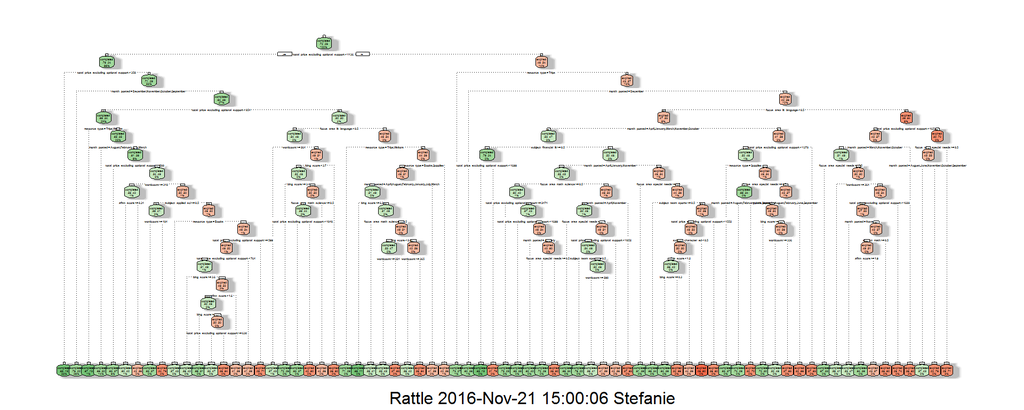

```r
library(rattle)
fancyRpartPlot(modelcart, palettes = c("Greens", "Reds"))
```

The accuracy of the model on the training set is (90947+9781)/134037 = 0.7515

The baseline model (where all projects are predicted as “completed”) has an accuracy of (90947 + 5564)/134037 = 0.7200

The CART model is a modest improvement over the baseline model

The accuracy of the model on the test set is (38791 + 4066)/57445 = 0.7461

The baseline model has an accuracy of (38791 + 2571)/57445 = 0.7200

The CART model is also a modest improvement over the baseline model for the test set.